# Tarea 2 TAE

Natalia Ramírez Ossa

25/11/2020

# Sección 8.4: Métodos Basados en Árboles

**7.** En el laboratorio, aplicamos bosques aleatorios a los datos de Boston usando mtry = 6 y usando ntree = 25 y ntree = 500. Cree un gráfico que muestre el error de prueba resultante de bosques aleatorios en este conjunto de datos para obtener un rango más completo de valores para mtry y ntree. Puede modelar su diagrama según la Figura 8.10. Describe los resultados obtenidos.

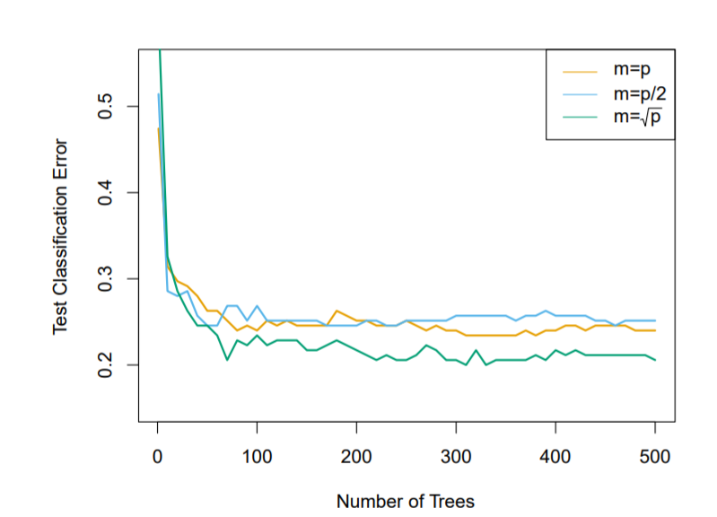

*Figura 8.10 (Libro)*

```r
library(randomForest)
```

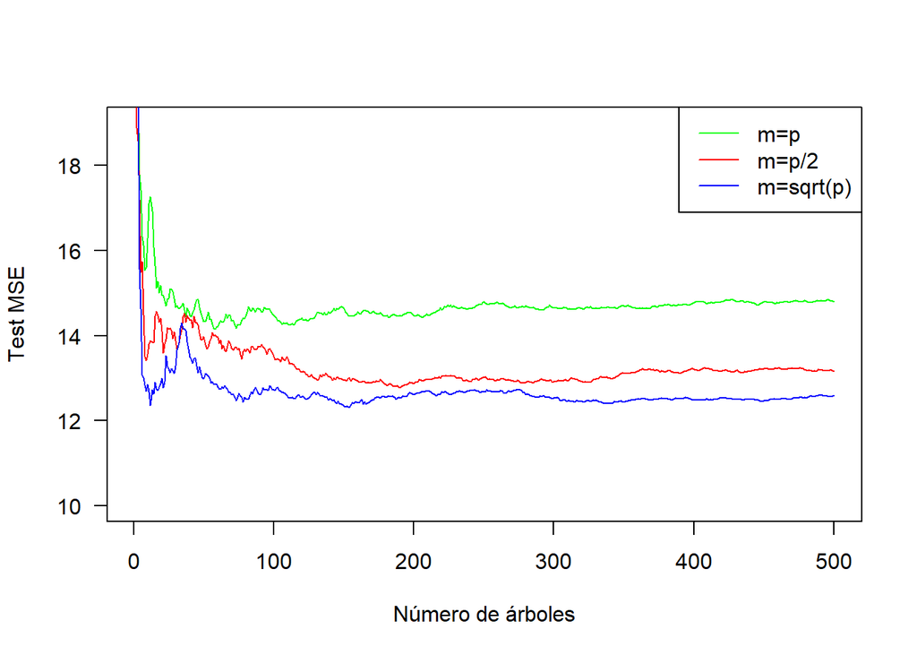

```r
library(MASS)

set.seed(123)

train <- sample(dim(Boston)[1], dim(Boston)[1]/2)
train_1 <- Boston[train, -14]
test_1 <- Boston[-train, -14]
train_2 <- Boston[train, 14]
test_2 <- Boston[-train, 14]

p <- dim(Boston)[2] - 1
p2 <- p/2
pr <- sqrt(p)

mod_p <- randomForest(train_1, train_2, xtest = test_1, ytest = test_2,
                          mtry = p, ntree = 500)
mod_p2 <- randomForest(train_1, train_2, xtest = test_1, ytest = test_2,
                           mtry = p2, ntree = 500)
mod_pr <- randomForest(train_1, train_2, xtest = test_1, ytest = test_2,
                           mtry = pr, ntree = 500)

plot(1:500, mod_p$test$mse, col = "green", type = "l", xlab = "Número de árboles",
     ylab = "Test MSE", ylim = c(10, 19),las=1)
lines(1:500, mod_p2$test$mse, col = "red", type = "l")
lines(1:500, mod_pr$test$mse, col = "blue", type = "l")
legend("topright", c("m=p", "m=p/2", "m=sqrt(p)"), col = c("green", "red", "blue"),
       cex = 1, lty = 1)
```

Graficamente podemos observar el resultado de bosques aleatorios para el conjunto de datos Boston (Valores de la vivienda en los suburbios de Boston), donde el error de prueba $(MSE)$ se reduce en la medida que se van agregando más árboles y tiende a estabilizarse alredor de 80 árboles. El valor de $m$ representa el número de predictores disponibles para dividir cada nodo del árbol y se llega a la conclusión que entre menor sea el valor de p, es decir $m<p$ se tiene un menor MSE y por lo tanto hay una mejora en el modelo.

**8.** En el laboratorio, se aplicó un árbol de clasificación al conjunto de datos de Asientos para automóvil después de convertir Ventas en una variable de respuesta cualitativa. Ahora buscaremos predecir las ventas utilizando árboles de regresión y enfoques relacionados, tratando la respuesta como una variable cuantitativa.

**(a)** Divida el conjunto de datos en un conjunto de entrenamiento y un conjunto de prueba.

```r
library(ISLR)
attach(Carseats)
train <- sample(dim(Carseats)[1], dim(Carseats)[1]/2)
train_Carseats <- Carseats[train, ]
test_Carseats <- Carseats[-train, ]
```

**(b)** Ajuste un árbol de regresión al conjunto de entrenamiento. Trace el árbol e interprete los resultados. ¿Qué tasa de error de prueba obtiene?

```r
library(tree)
set.seed(1234)
tree_Carseats <- tree(Sales ~ ., data = train_Carseats)
summary(tree_Carseats)
```

```
##
## Regression tree:
## tree(formula = Sales ~ ., data = train_Carseats)
## Variables actually used in tree construction:
## [1] "ShelveLoc"   "Price"       "Age"         "Income"      "CompPrice"
## [6] "Advertising" "Education"
## Number of terminal nodes:  18
## Residual mean deviance:  2.086 = 379.6 / 182
## Distribution of residuals:
##     Min.  1st Qu.   Median     Mean  3rd Qu.     Max.
## -3.61500 -0.94180 -0.01444  0.00000  0.87120  4.73900
```

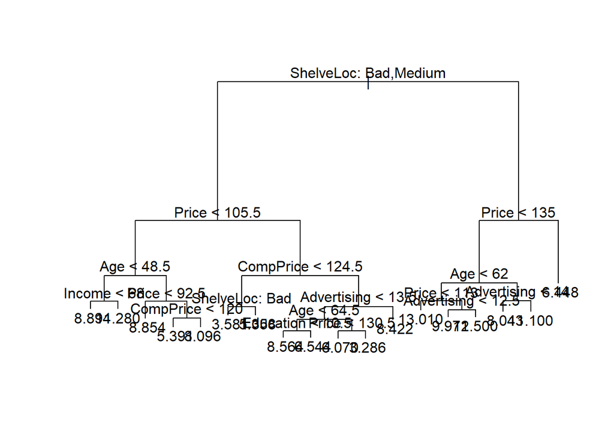

```r
plot(tree_Carseats)
text(tree_Carseats, pretty = 0)
```

```r
set.seed(1234)
pred_Carseats <- predict(tree_Carseats, test_Carseats)
mean((test_Carseats$Sales - pred_Carseats)^2)
```

```
## [1] 5.04945
```

La tasa de error de pruena (MSE) es de 5.04945

**(c)** Utilice la validación cruzada para determinar el nivel óptimo de complejidad del árbol. ¿La poda del árbol mejora la tasa de error de prueba?

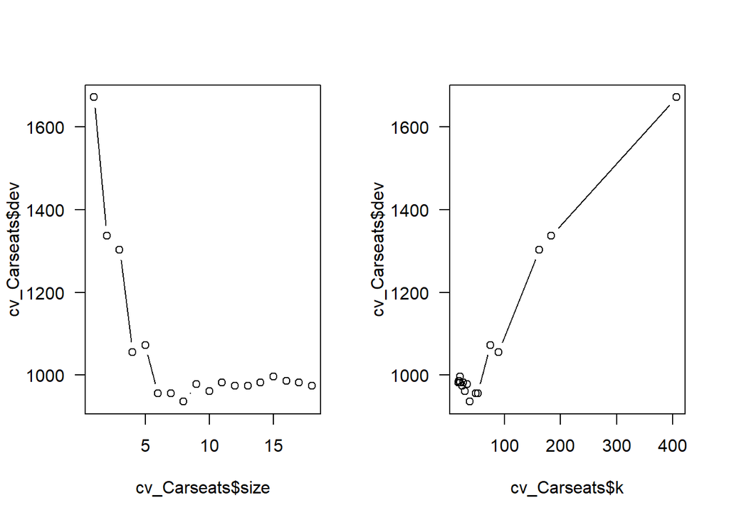

```r
set.seed(1234)
cv_Carseats <- cv.tree(tree_Carseats, FUN = prune.tree)
par(mfrow = c(1, 2))
plot(cv_Carseats$size, cv_Carseats$dev, type = "b", las=1)
plot(cv_Carseats$k, cv_Carseats$dev, type = "b",las=1)
```

El nivel óptimo de complejidad del árbol es de 8 árboles.

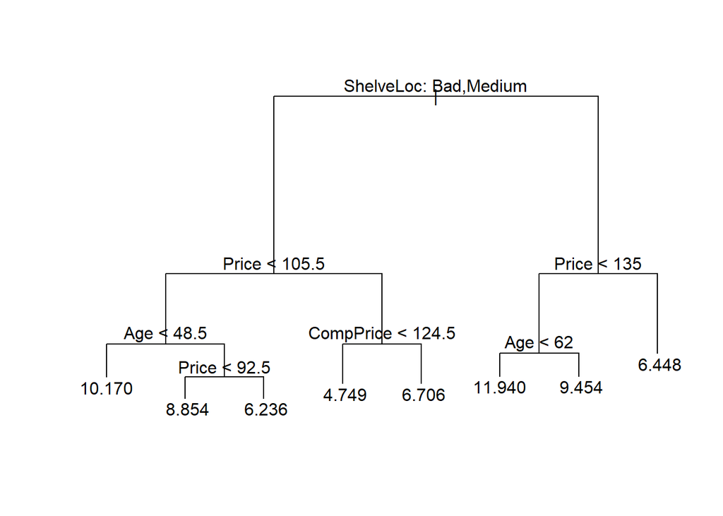

```r
p_Carseats <- prune.tree(tree_Carseats, best = 8)
par(mfrow = c(1, 1))
plot(p_Carseats)
text(p_Carseats, pretty = 0)
```

```r
ppruned <- predict(p_Carseats, test_Carseats)
mean((test_Carseats$Sales - ppruned)^2)
```

```
## [1] 5.176175
```

La tasa de error de prueba (MSE) es de 5.176175, por lo tanto incrementó el test del MSE.

**(d)** Utilice el método de ensacado para analizar estos datos. Qué tasa de error de prueba que obtiene? Utilice la función de importancia () para determinar qué variables son más importantes.

```r
library(randomForest)
set.seed(1234)
embolsado_Carseats <- randomForest(Sales ~ ., data = train_Carseats, mtry = 10, ntree = 500,
                                   importance = T)
embolsado_pred <- predict(embolsado_Carseats, test_Carseats)
mean((test_Carseats$Sales - embolsado_pred)^2)
```

```
## [1] 2.848948
```

La tasa de error de prueba (MSE) es de 2.848948

```r
importance(embolsado_Carseats)
```

```
##                %IncMSE IncNodePurity
## CompPrice   27.9403243    158.939637
## Income       4.6352465     77.713391
## Advertising 18.9811920    145.783548
## Population   1.7193473     64.825650
## Price       57.4228813    530.331700
## ShelveLoc   50.2702322    440.059053
## Age         13.9393273    137.823908
## Education    1.8760351     37.051520
## Urban        0.5622403      6.920209
## US          -1.0900962      7.895633
```

El método de embolsado mejora el error de prueba (MSE), las mejores variables en orden de importancia usando la función importance() vendrían siendo Price, ShelveLoc, CompPrice, Advertising y Age.

**(e)** Utilice bosques aleatorios para analizar estos datos. ¿Qué tasa de error de prueba obtiene? Utilice la función de importancia () para determinar qué variables son más importantes. Describa el efecto de m, el número de variables consideradas en cada división, sobre la tasa de error obtenida.

```r
bosques_Carseats <- randomForest(Sales ~ ., data = train_Carseats, mtry = 8, ntree = 500,
                                importance = T)
bosques_pred <- predict(bosques_Carseats, test_Carseats)
mean((test_Carseats$Sales - bosques_pred)^2)
```

```
## [1] 2.806753
```

```r
importance(bosques_Carseats)
```

```
##               %IncMSE IncNodePurity
## CompPrice   26.575672    152.033146
## Income       6.573620     82.420714
## Advertising 20.395156    154.918082
## Population   1.285095     70.486396
## Price       54.721022    519.258570
## ShelveLoc   49.963806    431.993389
## Age         16.246631    140.500587
## Education    2.525286     38.041132
## Urban        2.068834      8.446348
## US           3.329831      9.783475
```

El error de prueb (MSE) mejora ligeramente usando bosques aleatorios, las variables que mejor predicen las ventas siguen siendo ShelveLoc, Price, CompPrice y Advertising. El valor de m es 8 con este se disminuye error de prueba.

**9.** Este problema involucra al conjunto de datos de OJ que hace parte del paquete ISLR.

*a)* Crear un conjunto de entrenamiento que contenga una muestra aleatoria de 800 observaciones, y un conjunto de pruebas que contiene las observaciones restantes.

```r
attach(OJ)
train <- sample(dim(OJ)[1], 800)
OJtrain <- OJ[train, ]
OJtest <- OJ[-train, ]
```

*b)* Ajustar un árbol a los datos de entrenamiento, con la respuesta “Purchase”. y las otras variables como predictores. Utilice la función summary() para producir estadísticas resumidas sobre el árbol, y describir la resultados obtenidos. ¿Cuál es la tasa de error de entrenamiento? ¿Cuántos nodos terminales que tiene el árbol?

```r
set.seed(1234)
OJtree <- tree(Purchase ~ ., data = OJtrain)
summary(OJtree)
```

```
##
## Classification tree:
## tree(formula = Purchase ~ ., data = OJtrain)
## Variables actually used in tree construction:
## [1] "LoyalCH"       "PriceDiff"     "ListPriceDiff"
## Number of terminal nodes:  7
## Residual mean deviance:  0.771 = 611.4 / 793
## Misclassification error rate: 0.1662 = 133 / 800
```

*c)* Escriba el nombre del objeto de árbol para obtener una salida de texto detallada. Elija uno de los nodos terminales e interprete la información que se muestra.

```r
OJtree
```

```
## node), split, n, deviance, yval, (yprob)
##       * denotes terminal node
##
##  1) root 800 1069.00 CH ( 0.61125 0.38875 )
##    2) LoyalCH < 0.482935 300  328.30 MM ( 0.23667 0.76333 )
##      4) LoyalCH < 0.0356415 54    0.00 MM ( 0.00000 1.00000 ) *
##      5) LoyalCH > 0.0356415 246  295.60 MM ( 0.28862 0.71138 )
##       10) PriceDiff < 0.31 197  214.10 MM ( 0.23350 0.76650 ) *
##       11) PriceDiff > 0.31 49   67.91 CH ( 0.51020 0.48980 ) *
##    3) LoyalCH > 0.482935 500  446.20 CH ( 0.83600 0.16400 )
##      6) LoyalCH < 0.764572 241  292.20 CH ( 0.70539 0.29461 )
##       12) PriceDiff < -0.165 35   37.63 MM ( 0.22857 0.77143 ) *
##       13) PriceDiff > -0.165 206  213.70 CH ( 0.78641 0.21359 )
##         26) ListPriceDiff < 0.16 35   48.26 CH ( 0.54286 0.45714 ) *
##         27) ListPriceDiff > 0.16 171  152.50 CH ( 0.83626 0.16374 ) *
##      7) LoyalCH > 0.764572 259   91.02 CH ( 0.95753 0.04247 ) *
```

*d)* Crear un gráfico del árbol e interpretar los resultados.

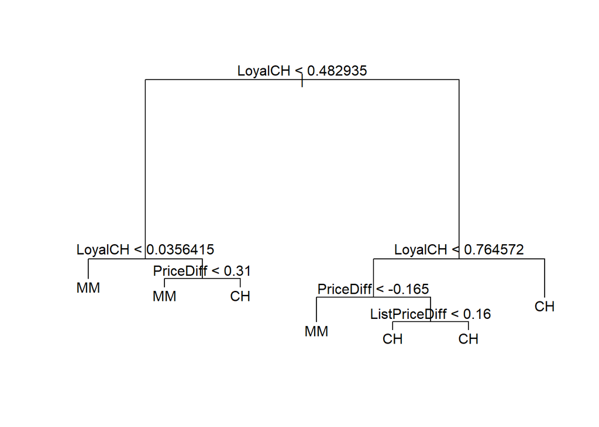

```r
plot(OJtree)
text(OJtree, pretty = 0)
```

*e)* Predecir la respuesta en los datos de la prueba, y producir una confusión matriz que compara las etiquetas de las pruebas con las etiquetas de las pruebas previstas. ¿Cuál es la tasa de error de la prueba?

```r
set.seed(1234)
OJpred <- predict(OJtree, OJtest, type = "class")
table(OJtest$Purchase, OJpred)
```

```
##     OJpred
##       CH  MM
##   CH 146  18
##   MM  34  72
```

*f)* Aplicar la función cv.tree() al conjunto de entrenamiento para determinar el tamaño óptimo del árbol.

```r
OJcv = cv.tree(OJtree, FUN = prune.tree)
```

*g)* Elaborar un gráfico con el tamaño del árbol en el eje x y validarlo de forma cruzada tasa de error de clasificación en el eje Y.

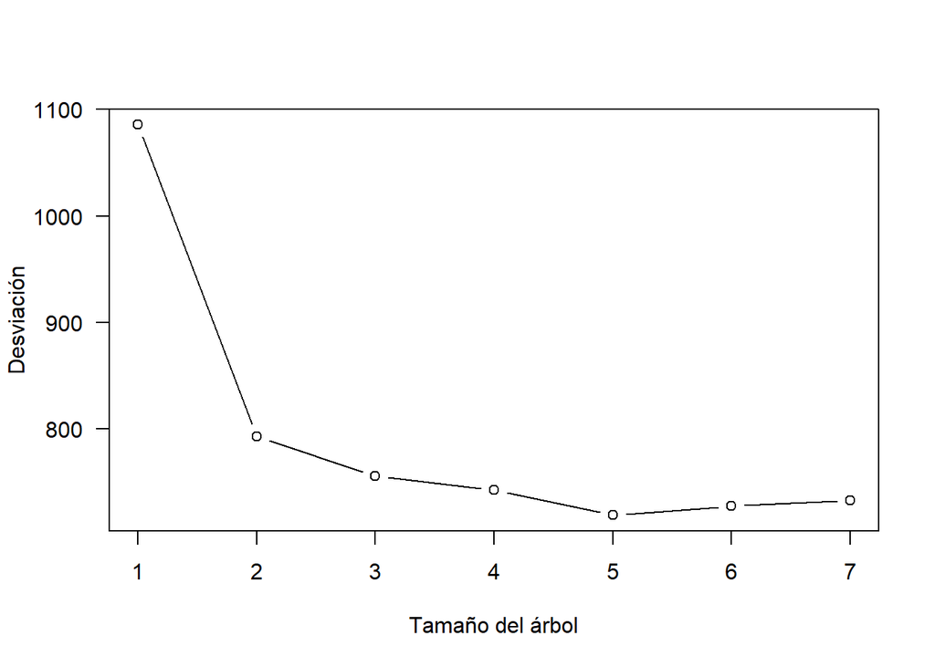

```r
plot(OJcv$size, OJcv$dev, type = "b", xlab = "Tamaño del árbol", ylab = "Desviación",las=1)
```

*h)* ¿Qué tamaño de árbol corresponde a la clasificación validada cruzada más baja tasa de error?

Un tamaño de 5 arrojaría la menor tasa de error de validación cruzada.

*i)* Producir un árbol podado que corresponda al tamaño óptimo del árbol obtenido mediante validación cruzada. Si la validación cruzada no conduce a la selección de un árbol podado, luego crear un árbol podado con cinco nodos terminales.

```r
set.seed(1234)
p_OJ <- prune.tree(OJtree, best = 6)
p_OJ
```

```
## node), split, n, deviance, yval, (yprob)
##       * denotes terminal node
##
##  1) root 800 1069.00 CH ( 0.61125 0.38875 )
##    2) LoyalCH < 0.482935 300  328.30 MM ( 0.23667 0.76333 )
##      4) LoyalCH < 0.0356415 54    0.00 MM ( 0.00000 1.00000 ) *
##      5) LoyalCH > 0.0356415 246  295.60 MM ( 0.28862 0.71138 )
##       10) PriceDiff < 0.31 197  214.10 MM ( 0.23350 0.76650 ) *
##       11) PriceDiff > 0.31 49   67.91 CH ( 0.51020 0.48980 ) *
##    3) LoyalCH > 0.482935 500  446.20 CH ( 0.83600 0.16400 )
##      6) LoyalCH < 0.764572 241  292.20 CH ( 0.70539 0.29461 )
##       12) PriceDiff < -0.165 35   37.63 MM ( 0.22857 0.77143 ) *
##       13) PriceDiff > -0.165 206  213.70 CH ( 0.78641 0.21359 ) *
##      7) LoyalCH > 0.764572 259   91.02 CH ( 0.95753 0.04247 ) *
```

*j)* Comparar las tasas de error de entrenamiento entre los podados y los no podados árboles. ¿Cuál es más alto?

```r
summary(p_OJ)
```

```
##
## Classification tree:
## snip.tree(tree = OJtree, nodes = 13L)
## Variables actually used in tree construction:
## [1] "LoyalCH"   "PriceDiff"
## Number of terminal nodes:  6
## Residual mean deviance:  0.7864 = 624.4 / 794
## Misclassification error rate: 0.1662 = 133 / 800
```

*k)* Comparar los índices de error de la prueba entre los podados y los no podados árboles. ¿Cuál es más alto?

```r
set.seed(1234)
p_NOpruned <- predict(OJtree, OJtest, type = "class")
badNopruned <- sum(OJtest$Purchase != p_NOpruned)
badNopruned/length(p_NOpruned)
```

```
## [1] 0.1925926
```

```r
set.seed(1234)
p_pruned <- predict(p_OJ, OJtest, type = "class")
badpruned = sum(OJtest$Purchase != p_pruned)
badpruned/length(p_pruned)
```

```
## [1] 0.1925926
```

**12.** Aplicar el potenciamiento, el embolsamiento y los bosques aleatorios a un conjunto de datos de su elección. Asegúrate de que los modelos encajen en datos de entrenamiento y de que evalúen su rendimiento en datos de prueba. ¿Cómo de precisos son los resultados comparados a métodos simples como la regresión lineal o logística? ¿Cuál de estos que los enfoques de la investigación dan el mejor resultado?

Por comodidad se usará la base de datos Caravan.

```r
train <- 1:1000
library(tidyverse)
Caravan <- Caravan%>%
  mutate(Purchase=case_when(Purchase == "Yes" ~ 1, TRUE~0))
Ctrain <- Caravan[train, ]
Ctest <- Caravan[-train, ]
```

```r
#Usando regresión logistica
logist <- glm(Purchase ~ ., data = Ctrain, family = binomial)
logistp <- predict(logist, Ctest, type = "response")
prediccion <- ifelse(logistp > 0.2, 1, 0)
table(Ctest$Purchase, prediccion)
```

```
##    prediccion
##        0    1
##   0 4183  350
##   1  231   58
```

El error de prueba es de 12.04%

```r
#Usando potenciamiento
set.seed(1234)
library(gbm)
cpotencido <- gbm(Purchase ~ ., data = Ctrain, n.trees = 1000, shrinkage = 0.01,
    distribution = "bernoulli")
potenciado <- predict(cpotencido, Ctest, n.trees = 1000, type = "response")
potenciadop <- ifelse(potenciado > 0.2, 1, 0) #mayor a 20%
table(Ctest$Purchase, potenciadop)
```

```
##    potenciadop
##        0    1
##   0 4406  127
##   1  258   31
```

Test de error es de 7.98%

```r
#Usando embolsamiento
set.seed(1234)
cembolsado <- randomForest(Purchase ~ ., data = Ctrain, mtry = 6)
cpredembolsado <- predict(cembolsado, newdata = Ctest)
embolsadop <- ifelse(cpredembolsado > 0.2, 1, 0) #mayor a 20%
table(embolsadop, Ctest$Purchase)
```

```
##
## embolsadop    0    1
##          0 4310  249
##          1  223   40
```

Test de error es de 9.78%

```r
#Usando bosques aleatorios
set.seed(1234)
cbosques <- randomForest(Purchase ~ ., data = Ctrain, mtry = 2)
cbosquesp <- predict(cbosques, newdata = Ctest)
bp <- ifelse(cbosquesp > 0.2, 1, 0) #mayor a 20%
table(bp, Ctest$Purchase)
```

```
##
## bp     0    1
##   0 4447  270
##   1   86   19
```

Test de error es de 7.38%

El test de error mas bajo fue el de bosques aleatorios.